# Skin FACS Notebook

Enter the directory of the maca folder on your drive and the name of the tissue you want to analyze.

```r
tissue_of_interest = "Skin"
```

```
[1] "Scaling data matrix"
```

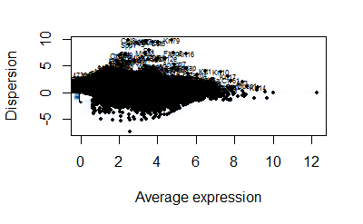

```r
library(here)
source(here("00_data_ingest", "02_tissue_analysis_rmd","boilerplate.R"))
tiss <- load_tissue_facs(tissue_of_interest)
```

```r
cells = rownames(tiss@meta.data)[is.na(tiss@meta.data$subtissue)]
tiss = SubsetData(tiss, cells.use = cells)
```

A sanity check: genes per cell vs reads per cell.

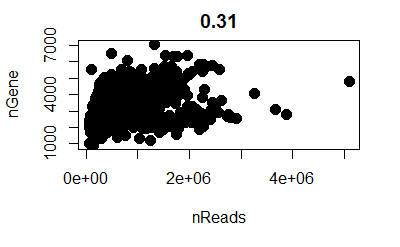

```r
GenePlot(object = tiss, gene1 = "nReads", gene2 = "nGene", use.raw=T)
```

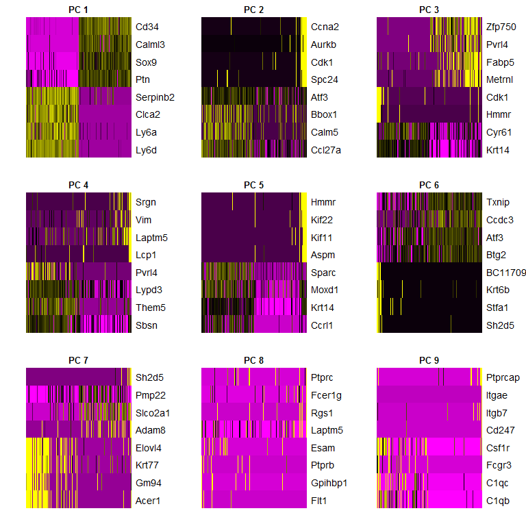

Later on (in FindClusters and TSNE) you will pick a number of principal components to use. This has the effect of keeping the major directions of variation in the data and, ideally, supressing noise. There is no correct answer to the number to use, but a decent rule of thumb is to go until the plot plateaus.

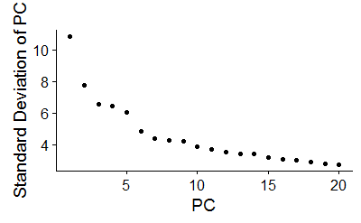

```r
PCElbowPlot(object = tiss)
```

Choose the number of principal components to use.

```r
# Set number of principal components.
n.pcs = 5
```

The clustering is performed based on a nearest neighbors graph. Cells that have similar expression will be joined together. The Louvain algorithm looks for groups of cells with high modularity–more connections within the group than between groups. The resolution parameter determines the scale…higher resolution will give more clusters, lower resolution will give fewer.

For the top-level clustering, aim to under-cluster instead of over-cluster. It will be easy to subset groups and further analyze them below.

```r
# Set resolution
res.used <- 0.4
tiss <- FindClusters(object = tiss, reduction.type = "pca", dims.use = 1:n.pcs,
    resolution = res.used, print.output = 0, save.SNN = TRUE)
```

To visualize

```r
# If cells are too spread out, you can raise the perplexity. If you have few cells, try a lower perplexity (but never less than 10).
tiss <- RunTSNE(object = tiss, dims.use = 1:n.pcs, seed.use = 10, perplexity=30)
```

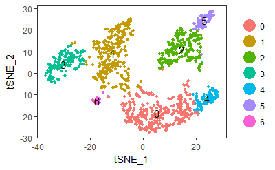

```r
# note that you can set do.label=T to help label individual clusters
TSNEPlot(object = tiss, do.label = T)
```

Check expression of genes of interset.

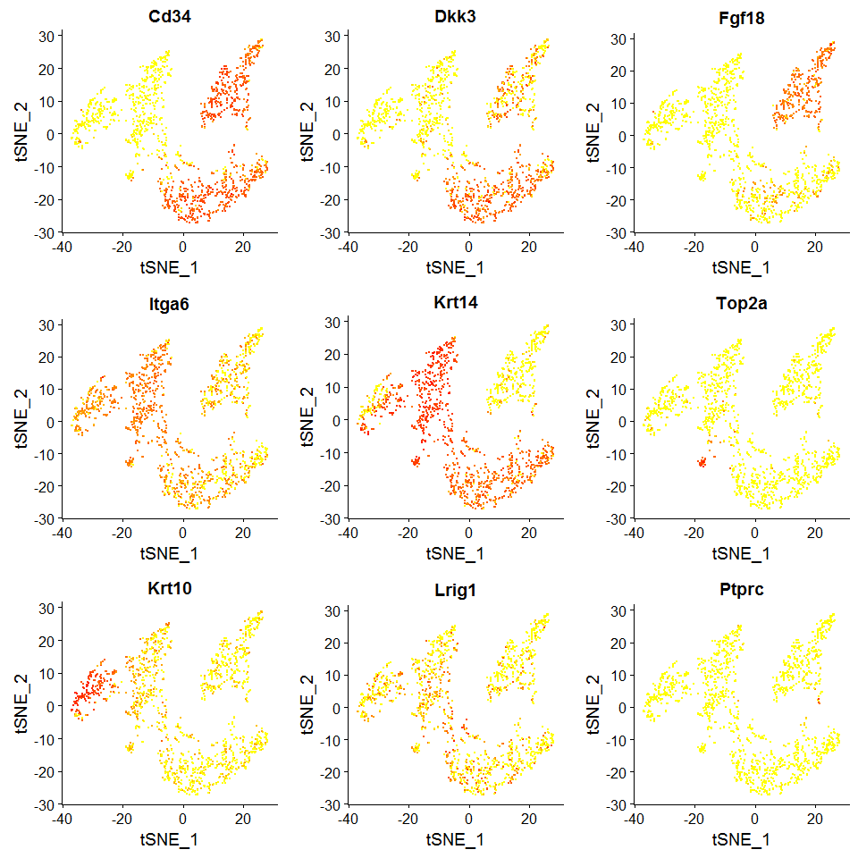

Dotplots let you see the intensity of exppression and the fraction of cells expressing for each of your genes of interest.

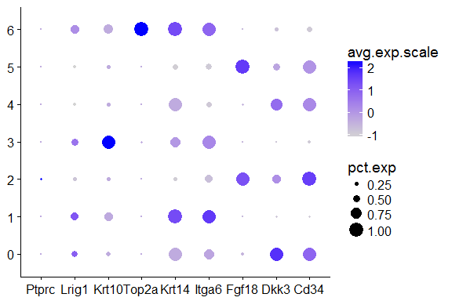

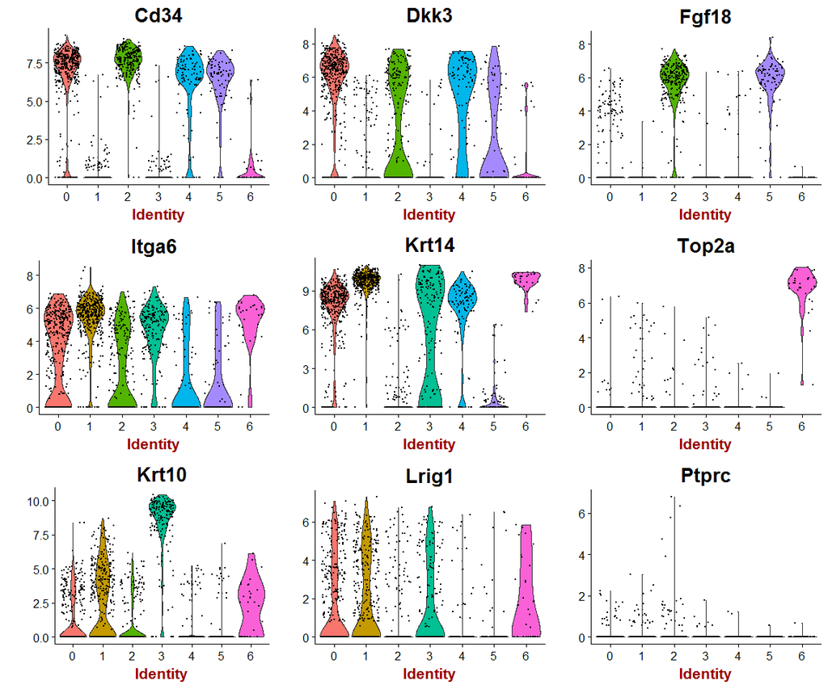

How big are the clusters?

```r
table(tiss@ident)
```

```
  0   1   2   3   4   5   6
411 376 255 181  96  81  31
```

Which markers identify a specific cluster?

```r
clust.markers <- FindMarkers(object = tiss, ident.1 = 0, only.pos = TRUE, min.pct = 0.25, thresh.use = 0.25)
```

```r
print(x = head(x= clust.markers, n = 10))
```

[output not shown]

You can also compute all markers for all clusters at once. This may take some time.

```r
tiss.markers <- FindAllMarkers(object = tiss, only.pos = TRUE, min.pct = 0.25, thresh.use = 0.25)
```

[output not shown]

[output cut: 654 more lines]

[output not shown]

Display the top markers you computed above.

```r
tiss.markers %>% group_by(cluster) %>% top_n(15, avg_logFC)
```

| p_val | avg_logFC | pct.1 | pct.2 | p_val_adj | cluster | gene |
| --- | --- | --- | --- | --- | --- | --- |
| 5.139748e-137 | 1.939495 | 0.869 | 0.177 | 1.199669e-132 | 0 | Ctgf |
| 4.119378e-105 | 1.981182 | 0.815 | 0.224 | 9.615039e-101 | 0 | Hmcn1 |
| 5.686728e-103 | 2.377115 | 0.642 | 0.104 | 1.327339e-98 | 0 | Trpv4 |
| 1.050977e-100 | 2.187507 | 0.669 | 0.126 | 2.453084e-96 | 0 | Krt24 |
| 1.467146e-80 | 2.183965 | 0.667 | 0.205 | 3.424467e-76 | 0 | Igfbp4 |
| 1.676791e-77 | 2.384144 | 0.411 | 0.032 | 3.913797e-73 | 0 | Camk4 |
| 5.176343e-72 | 2.166136 | 0.533 | 0.104 | 1.208210e-67 | 0 | Npnt |
| 8.742129e-62 | 2.635454 | 0.360 | 0.037 | 2.040500e-57 | 0 | Angptl7 |
| 5.019016e-60 | 2.203439 | 0.448 | 0.082 | 1.171488e-55 | 0 | Nedd9 |
| 3.441727e-52 | 2.102826 | 0.404 | 0.075 | 8.033335e-48 | 0 | Col12a1 |

[output cut: 95 more lines]

## Assigning cell type identity to clusters

At a coarse level, we can use canonical markers to match the unbiased clustering to known cell types:

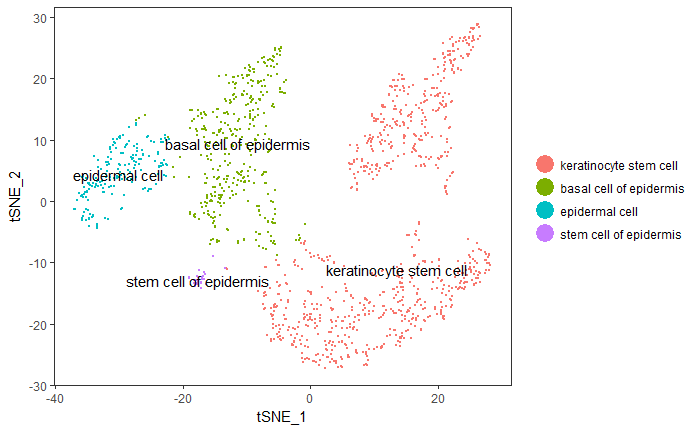

```r
# stash current cluster IDs
tiss <- StashIdent(object = tiss, save.name = "cluster.ids")
# enumerate current cluster IDs and the labels for them
cluster.ids <- c(0, 1, 2, 3, 4, 5, 6)
free_annotation <- c("Outer Bulge","Basal IFE","Inner Bulge","Intermediate IFE","Outer Bulge","Inner Bulge","Replicating Basal IFE")
cell_ontology_class <-c ("keratinocyte stem cell","basal cell of epidermis", "keratinocyte stem cell","epidermal cell","keratinocyte stem cell","keratinocyte stem cell","stem cell of epidermis")
cell_ontology_id <-c ("CL:0002337","CL:0002187","CL:0002337","CL:0000362","CL:0002337","CL:0002337","CL:1000428")
tiss@meta.data[,'free_annotation'] <- NA
tiss@meta.data[,'cell_ontology_class'] <- plyr::mapvalues(x = tiss@ident, from = cluster.ids, to = cell_ontology_class)
tiss@meta.data[,'cell_ontology_id'] <- plyr::mapvalues(x = tiss@ident, from = cluster.ids, to = cell_ontology_id)
tiss@meta.data[tiss@cell.names,'cell_ontology_class'] <- as.character(tiss@meta.data$cell_ontology_class)
tiss@meta.data[tiss@cell.names,'cell_ontology_id'] <- as.character(tiss@meta.data$cell_ontology_id)
TSNEPlot(object = tiss, do.label = TRUE, pt.size = 0.5, group.by='cell_ontology_class')
```

## Checking for batch effects

Color by metadata, like plate barcode, to check for batch effects.

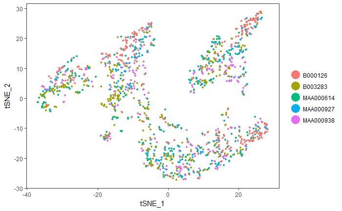

```r
TSNEPlot(object = tiss, do.return = TRUE, group.by = "plate.barcode")
```

```r
TSNEPlot(object = tiss, do.return = TRUE, group.by = "mouse.sex")
```

[output not shown]

```r
TSNEPlot(object = tiss, do.return = TRUE, group.by = "subtissue")
```

```
Error in seq.default(h[1], h[2], length.out = n) :
  'to' must be a finite number
```

# Final coloring

Color by cell ontology class on the original TSNE.

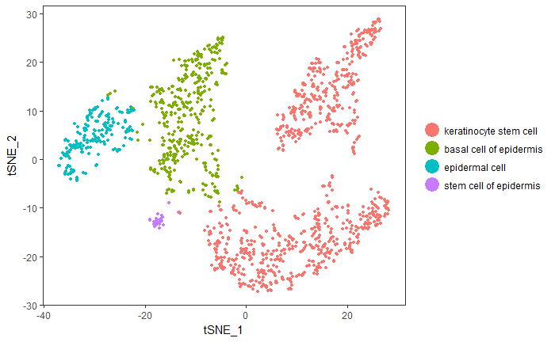

```r
TSNEPlot(object = tiss, do.return = TRUE, group.by = "cell_ontology_class")
```

```r
table(tiss@meta.data[["cell_ontology_class"]])
```

```
 keratinocyte stem cell basal cell of epidermis          epidermal cell  stem cell of epidermis
                    843                     376                     181                      31
```

Print a table showing the count of cells in each identity category from each plate.

```r
table(as.character(tiss@ident), as.character(tiss@meta.data$plate.barcode))
```

```
    B000126 B003283 MAA000614 MAA000927 MAA000938
  0      71     100        84        79        77
  1     110      96        46        65        59
  2      15      70        59        47        64
  3      27      63        43        20        28
  4      60       6        10        14         6
  5      59       5         2        14         1
  6       6       8         8         1         8
```

```r
table(as.character(tiss@ident), as.character(tiss@meta.data$tissue))
```

```
    Skin
  0  411
  1  376
  2  255
  3  181
  4   96
  5   81
  6   31
```

```r
table(as.character(tiss@ident), as.character(tiss@meta.data$subtissue))
```

```
< table of extent 7 x 0 >
```

```r
table(as.character(tiss@ident), as.character(tiss@meta.data$mouse.sex))
```

```
      F   M
  0 171 240
  1 206 170
  2  85 170
  3  90  91
  4  66  30
  5  64  17
  6  14  17
```

# Save the Robject for later

When you save the annotated tissue, please give it a name.

```r
filename = here('00_data_ingest', '04_tissue_robj_generated',
                     paste0("facs", tissue_of_interest, "_telogen_seurat_tiss.Robj"))
print(filename)
```

```
[1] "C:/Users/Nick/Documents/GitHub/additional/tabula-muris/00_data_ingest/04_tissue_robj_generated/facsSkin_telogen_seurat_tiss.Robj"
```

```r
save(tiss, file=filename)
```

```r
# To reload a saved object
# filename = here('00_data_ingest', '04_tissue_robj_generated',
#                      paste0("facs", tissue_of_interest, "_seurat_tiss.Robj"))
# load(file=filename)
```

# Export the final metadata

So that Biohub can easily combine all your cell_ontology_classes, please export them as a simple csv.

```r
head(tiss@meta.data)
```

|  | nGene | nReads | orig.ident | plate.barcode | mouse.id | tissue | subtissue | FACS.selection | mouse.sex | percent.ercc | free_annotation | cell_ontology_class | percent.ribo | res.0.4 | cluster.ids | cell_ontology_id |
| --- | --- | --- | --- | --- | --- | --- | --- | --- | --- | --- | --- | --- | --- | --- | --- | --- |
| A1.B000126.3_39_F.1.1 | 3125 | 599257 | Skin | B000126 | 3_39_F | Skin | NA | Multiple | F | 0.022510142 | NA | epidermal cell | 0.08357683 | 3 | 3 | CL:0000362 |
| A1.B003283.3_38_F.1.1 | 5543 | 2585048 | Skin | B003283 | 3_38_F | Skin | NA | Multiple | F | 0.004389080 | NA | epidermal cell | 0.04037449 | 3 | 3 | CL:0000362 |
| A1.MAA000614.3_10_M.1.1 | 3249 | 1044110 | Skin | MAA000614 | 3_10_M | Skin | NA | Multiple | M | 0.011212652 | NA | basal cell of epidermis | 0.05127046 | 1 | 1 | CL:0002187 |
| A1.MAA000938.3_8_M.1.1 | 4821 | 298187 | Skin | MAA000938 | 3_8_M | Skin | NA | Multiple | M | 0.005599168 | NA | stem cell of epidermis | 0.02913943 | 6 | 6 | CL:1000428 |
| A10.B000126.3_39_F.1.1 | 2552 | 339047 | Skin | B000126 | 3_39_F | Skin | NA | Multiple | F | 0.024271831 | NA | keratinocyte stem cell | 0.06908482 | 4 | 4 | CL:0002337 |
| A10.B003283.3_38_F.1.1 | 4628 | 1211986 | Skin | B003283 | 3_38_F | Skin | NA | Multiple | F | 0.005989556 | NA | epidermal cell | 0.05110125 | 3 | 3 | CL:0000362 |

```r
filename = here('00_data_ingest', '03_tissue_annotation_csv',
                     paste0(tissue_of_interest, "telogen_cell_ontology_class.csv"))
write.csv(tiss@meta.data[,c('plate.barcode','cell_ontology_class','cell_ontology_id')], file=filename)
```